# Insgihts on brand in marketing

Zhuyun XIAO, Huiru TAO, Yuejia XU

2016年5月2日

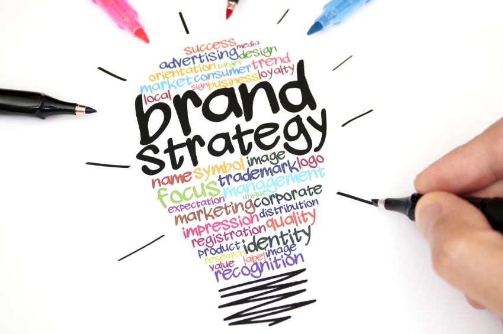

# Background and motivation

Based on the definition from American Marketing Associations, a brand is a name, term, sign, symbol, design, or a combination of them intended to identify the goods and services of one seller or group of sellers and to differentiate them from those of other seller.

Because of that economic function brand serves in the mind of the consumer, it is usually viewed as one of the most valuable marketing assets and stands at the core of marketing. Each year, companies spend millions of dollars on promoting better brands by making fascinating logos and launching commercial campaigns.

The value of the brand comes from its ability to gain an exclusive, positive and prominent meaning in the mind of a large number of customers. For example, a successful branding can promote consumer’s loyalty and allow saving of time and energy through identical repurchasing.<sup>1</sup> Understanding what influence brand perception would help firms perform better on positioning, marketing communication and customer relationship. Furthermore, a good brand would positively influence the word of mouth and in long run increase firms’ profits.

Fascinated by those values behind brand, our group is interested in getting an in depth understanding of brand in marketing. We would like to explore brand characteristics, figure out association between brand characteristics and products’ usage as well as understand how customers assign their regards based on different brand characteristics.

We hope that by doing this project, we can give suggestions to companies about how to brand more efficiently, which would help them perform better on positioning, marketing communication and customer relationship as well as reduce their expenditures on branding.

# Data description

We collected our data from a database<sup>2</sup> on brand characteristics, through the link provided [here](http://pubsonline.informs.org/doi/suppl/10.1287/mksc.2014.0861). There are two datasets available here and we use both of them in our project.

## First dataset: brand characters measured by 2010

The first dataset file named “Brand_Characteristics_Data_File.xlsx” contains 136 measures of brand characteristics for a cross section of 697 top national U.S. brands across 16 product and service categories measured by 2010. This dataset has three main sources.

The first data source is the survey conducted by the database developers. The survey measures additional brand characteristics such as brand familiarity, excitement, complexity, visibility, etc. Those data are valuable because respondents were screened to ensure a high level of brand familiarity. Therefore their answers accurately reflect their perception on brand (and minimize the chance of random guessing or inaccurate reports).

The second data source is secondary data. This part collects data from various sources and it contains information on brand’s age, brand’s category, satisfaction, etc.

The third compoentns of this dataset is Young and Rubicam’s BrandAsset Valuator. In particular, this data set includes information on 629 of the 697 brands and describes the most recent data point that was available at the end of the second quarter of 2010. They measured a broad array of perceptions and attitudes for a large number of brands. Examples of measurement include usage (the percentage of respondents who stated that they use the brand occasionally or often), Brand Personality (such as the extent to which the brand is regarded), Energized_Differentiation (the extent to which the brand is perceived as differentiated from other brands) and brand image (other customer mind-set measures such as “fun”, “Glamorous”, “healthy”, etc. ).

We summarize 3 data sources and their respective variables in the figure below.

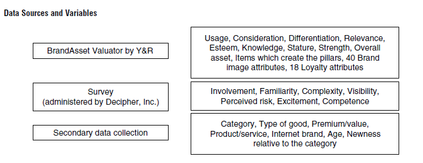

Using this data set, we are able to conduct various analysis on brand characteristics, as well as explore the relations between different sets of characteristics and dependent outcomes by2010 Quarter 2.

## Second dataset: BAV quarterly data from 2008Q1 to 2010Q2

We also have a second datafile named “disaggregate_BAV_data_total_dataonly.xlsx” (also contained in the zipped data folder).

This dataset includes quarterly information of 2008 Quarter 1 to 2010 Quarter 2. Similar to the third source of our first dataset, it also displays results provided by BAV Consulting group on a broad array of perceptions and attitudes for a large number of brands. However, what makes it different from the first dataset is that it keeps track for each brand for the 10 quarters. This feature of the dataset enables us to detect potential time patterns of various measurements from 2008Q1 to 2010Q2.

# Objectives

We have several questions that we want to address in this project.

1. Whether there is a time trend of brand usage?
2. Are customers’ perception of a brand associated with brand’s characteristics?
- If so, which one/more characters have association with customer’s perception?
- Are the association consistent across different brand categories?
3. Is there any relationship between the usage of a particular brand and age (absolute age) of that brand?
- What about the relationship between usage and newness relative to the product type?
- Which one is more associated with usage? Absolute age or relative age?
4. Among machine learning methods we learnt, which makes the best prediction for customers’ perception? Which one has the best ability to classify brand into correct categories?

# Analysis

## 1. Import, clean and wrangle dataset

We load the first BAV dataset for time trend analysis, since our excel file has multiple sheets, we want to read them in altogether, and combine them.

```r
library(readxl)
#Define a function to read all sheets
read_excel_allsheets<-function(filename) {
    sheets<-readxl::excel_sheets(filename)
    x<-lapply(sheets, function(X) readxl::read_excel(filename, sheet = X))
    names(x)<-sheets
    x
}

data<-read_excel_allsheets("disaggregate_BAV_data_total_dataonly.xlsx")
```

The first two worksheets are description rather than quarterly data, so we define a new list with only quareterly data. In addition. We only care about quarterly usage, so we extract this outcome from all excel worksheets.

```r
seasondata<-data[3:12]
quarter<-as.data.frame(lapply(seasondata, function(x) x[,4]))
#The first three rows do not contain data about usage
quarter<-quarter[-(1:3),]
```

Since the data are in factor level, we convert them into numeric for further analysis.

```r
indx<-sapply(quarter, is.factor)
quarter[indx]<-lapply(quarter[indx], function(x) as.numeric(as.character(x)))
```

We also extract brand information, bind quarter usage with brand name and change row names and column names of the timedata data frame.

```r
brand_info<-as.data.frame(seasondata[1])[-(1:3),1:3]
timedat<-cbind(brand_info,quarter)
rownames(timedat)<-NULL
colnames(timedat)[1:3]<-c("brand_id","brand_name","brand_category")
```

There are also some word “case” problems“. For example, some are code as”Department Stores“, while others are coded as”Department stores“, we unify the case in order to perform group-wise analysis later on.

```r
timedat$brand_category<-ifelse(timedat$brand_category=="Department Stores","Department stores",timedat$brand_category)
```

Then we load in the other dataset, which most our analysis base on.

```r
library(dplyr)
library(tidyr)
#Load
raw<-readxl::read_excel("Brand_Characteristics_Data_File.xlsx",sheet=2)
data<-data.frame(raw)
rownames(data) <-c(-2,-1,0,seq(1,701))
rowname<-data[rownames(data)==0,]
finedata<-data[!(rownames(data) %in% c(-2,-1,0,701,700,699,698)), ]
names(finedata)<-rowname
```

Remove all questions in survey and rename satisfaction and familiarity.

```r
#Remove and rename columns
newdata<-finedata%>%select(`Brand id`:`Satisfaction - ACSI`,Involvement,`Q5: Familiarity given familiarity with the category`,Complexity,Visibility,`Perceived risk`,Excitement,Competence,Total_Users_pct:Regard_MS)%>%rename(Familiarity=`Q5: Familiarity given familiarity with the category`,Satisfaction=`Satisfaction - ACSI`,Perceived_risk=`Perceived risk`, Newness=`Newness relative to the category`)%>%mutate(Internet=as.numeric(Internet),`Interbrand top list`=as.numeric(`Interbrand top list`),`Category  code`=as.numeric(`Category  code`),Newness=as.numeric(Newness),Age=as.numeric(Age))%>%rename(Interbrand_top_list=`Interbrand top list`,CatCode=`Category  code`)
```

Similar to the first dataset, there are some letter case problems that we need to unify for further analysis purpose.

```r
#Capital case to small case
newdata<-newdata%>%mutate(Category=ifelse(Category=="Department Stores","Department stores",Category))
newdata<-newdata%>%mutate(Category=ifelse(Category=="Household Products (cleaning ingredients etc.)","Household products (cleaning ingredients etc.)",Category))%>%mutate(Premium=ifelse(Premium=="MIddle","Middle",Premium))
```

Our data are not stored in numeric type, we convert our data from character to numeric.

```r
#use lapply to change columns that contain numerics but stored as "character" to "numeric"
newdata[,-(1:11)]<-lapply(newdata[,-(1:11)],function(x) as.numeric(x))
```

## 2.Time trend analysis

The second dataset have usage information that has been recorded for two and a half years on a quarterly basis. In real world, some brands’ usage has an obvious time pattern, such as long term decline, or regular fluctuations with time (might be due to seasonal effect). Given the quarterly data, We are interested in detecting whether time has an effect on brand usage.

Our analysis will be separated into two parts. The first part’s analysis is on the overall trend of different categories (average of all brands within a brand category), whereas the second analysis focus more on an individual brand-specific trend.

### 2.1 Time trend and seasonal effect analysis by category

The motivation of this analysis is that we expect some category such as Food and dining has some specific usage pattern (might be seasonal effect) with respect to time. For example, in Quarter 1, cold winter weather makes people unwilling to dine out, also there are several ice-cream brand in the Food and dining, thus the usage of “food and dining” category should be lower in Quarter 1. Given that usage data from 2008 Quarter 1 to 2010 Quarter 2 are all available to us at the current stage, we are curious about the time trend underlying of usage of different categories. To be specific, the outcome of interest in time trend analysis section is “Usage” (Recorded as Total_Users_pct in the dataset) and the covariate of interest is time.

We calculate the mean usage for each category in each quarter (summarize mean by brand_category).

```r
mean_dat<-timedat%>%group_by(brand_category)%>%summarize(t0=mean(X2008Q1,na.rm=TRUE),t1=mean(X2008Q2,na.rm=TRUE),t2=mean(X2008Q3,na.rm=TRUE),t3=mean(X2008Q4,na.rm=TRUE),t4=mean(X2009Q1,na.rm=TRUE),t5=mean(X2009Q2,na.rm=TRUE),t6=mean(X2009Q3,na.rm=TRUE),t7=mean(X2009Q4,na.rm=TRUE),t8=mean(X2010Q1,na.rm=TRUE),t9=mean(X2010Q2,na.rm=TRUE))
```

Then, we make plots to show the trend of those average usage of “all brands within each category” with time.

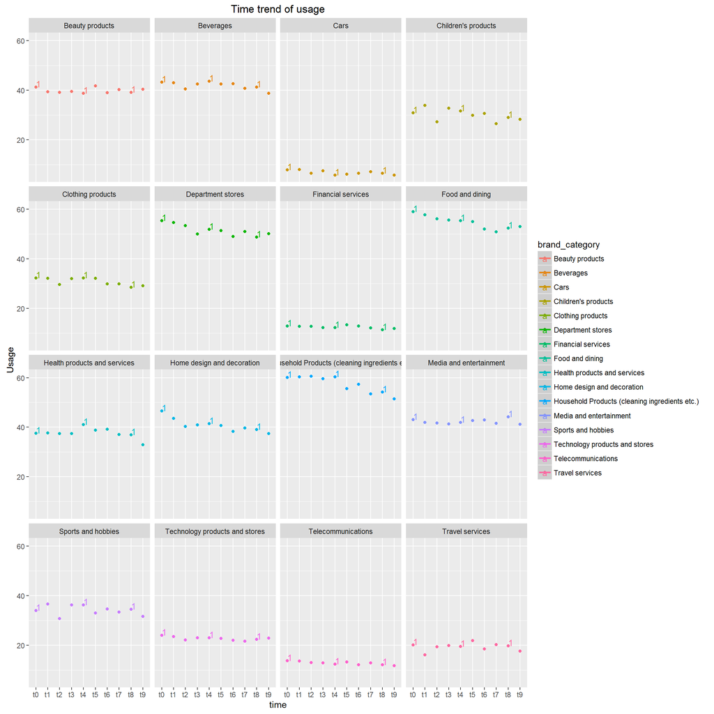

```r
#We make the mean data from wide format to long format by the "gather" function
mean_dat_long<-mean_dat%>%gather(time,mean_usage,-brand_category)

#We create a new column that indicates quarter 1 for later plotting annotation purpose
mean_dat_quarter_info<-mean_dat_long%>%mutate(Q=ifelse(time=="t0"|time=="t4"|time=="t8","1",NA) )

#In order to make the "Quarter" easily seen, we annotate points from Quarter 1, we do not annotate all the points, since the trend is quite flat, and annotating all points make it messy.
library(ggplot2)
mean_dat_quarter_info%>%
  ggplot(aes(x=time,y=mean_usage,color=brand_category))+
  ggtitle("Time trend of usage")+
  ylab("Usage")+
  geom_point()+
  geom_smooth()+
  geom_text(data=subset(mean_dat_quarter_info,time=="t0"|time=="t4"|time=="t8"),aes(label=Q),vjust=0,hjust=0)+
  facet_wrap(~brand_category)
```

Data points which has an “1” beside it indicates that this data is “Quarter 1” usage, thus the three subsequent data points represent Quarter 2, Quarter 3 and Quarter 4, respectively.

### 2.2 Time trend and seasonal effects analysis within category

Besides interested in the time pattern of the average usage in each category, we are also interested in the time trend of different brand within a specific brand category. For example, there are many brands (51) within the “Clothing products” category. We want to explore the difference in time trend of different clothing brand. Our group picks up 4 brands that we like best and compare by drawing the line plot on the same graph. In particular, we use “dygraphs” package to make the plot more interactive. In the figure we create below, you can select the brand of your interest by putting the mouse on that particular series, and the series will be highlighted. You can also move your mouse along a particular series and the individual values at different time point will be displayed. In addition, you can use the range selector at the bottom of the graph to pan and zoom the region of interest. (Note: X axis label indicates the starting month of a quarter)

```r
library(xts)
#"xts" function requires each row indicate a time point, however, each column of the "quarter" data represent time point, so we need to transpose and transform the transposed matrix into data frame
transquarter<-as.data.frame(t(quarter))
#Each row name has the form "Xyearquarter", we need to remove the initial "X" in order to convert to the data type that xts can recognize
rownames(transquarter)<-sapply(rownames(transquarter), function(x) substring(x,2))
#Put the row names of the data as the first column of this dataset,since xts cannot be applied to rownames
transquarter<-add_rownames(transquarter, "quarter")
#Convert the time indicator to a recognizable format
transquarter$quarter<-as.yearqtr(transquarter$quarter)
#Transform our dataset to "xts" format for further plotting purpose
xtsdata<-xts(transquarter[,-1], transquarter$quarter)
#Select 4 clothing brand that we are interested in: A&F, American Eagle, Ann Taylor and Banana Republic
A_F<-xtsdata[,7]
American_Eagle<-xtsdata[,29]
Ann_Talyor<-xtsdata[,36]
Banana<-xtsdata[,60]
#bind them and used the binded object as the data object for plotting
interestdata<-cbind(A_F,American_Eagle,Ann_Talyor,Banana)

#Make a dynamic graph by dygraph
library(dygraphs)
dygraph(interestdata,main="Usage of 4 clothing brands")%>%
  dySeries("X10", label = "A&F") %>%
  dySeries("X32", label = "American Eagle") %>%
  dySeries("X39", label = "Ann Talyor") %>%
  dySeries("X63", label = "Banana Republic")%>%
  dyRangeSelector(height = 20)%>%
  dyOptions(colors = RColorBrewer::brewer.pal(4, "Set1"))%>%
  dyHighlight(highlightCircleSize = 5,
              highlightSeriesBackgroundAlpha = 0.2,
              hideOnMouseOut = FALSE,
              highlightSeriesOpts = list(strokeWidth = 3))
```

[interactive chart not shown]

This plot is quite informative. We find that Banana Republic and American Eagle have higher usage than Ann Talyor and A&F most of the time. In terms of the time trend pattern, American Eagle and A&F display similar trend, the fluctuations are quite large, especially in 4 quarters of 2008. The lowest usage occurred in 3rd quarter of 2008 for American Eagle (Blue), whereas that of A&F (Red) occur in the first quarter of 2009. Usage of Banana Republic also fluctuate widely. The trend is similar to American Eagles in the first three quarters. Then, its trend becomes opposite to American Eagles’ from 4th quarter in 2008 to 2nd quarter in 2009 (American Eagle: decrease then increase; Banana Republic: increase then decrease). In 2010 Quarter 1 and Quarter 2, again, they have opposite patterns. (American Eagles increase from Q1 to Q2, while Banana Republic decrease from Q1 to Q2). The time pattern of Ann Tylor is quite different from the other 3 brands, it is relatively steady starting from 2009 Q1, despite a slight drop in 2009 Q3.

### 2.3 Some comments on time trend and seasonal effects analysis

We are trying to address Objective 1 in the time trend analysis above and we are able to get some feeling after visualizing the data. However, we are not able to provide a highly convincing answer at this stage, since in our dataset, the “follow-up period” is not long enough. So we are not able to determine a long-term trend of a very obvious and consistent seasonal effect based on available data. We definitely need more data to formally do a time series analysis.

Then, we are going to move to the other dataset, which contains not only the BAV data, but also more product characteristics (but only recorded at a single time point) from a new survey and other secondary data source. By analyzing this dataset, we are able to extend the breadth of our analysis.

## 3. Visually explore the dataset

### 3.1 Brand Category

In total we have 697 brands, and each brand falls into a category. We want to have an overall feeling of how many brands are contained in each brand category before filtering out.

```r
table(newdata$Category)
```

```
##
##                                Beauty products                                      Beverages                                           Cars                            Children's products                              Clothing products                              Department stores                …
##                                             52                                             66                                             47                                             19                                             51                                             15                …
```

### 3.2 Regard_MS (Primary outcome of interest)

Rgard_MS is the value related to how highly consumer think of a brand. It measures consumers’ perception of a brand and ranges between 1-7, where 1 means low regards while 7 means high regards.

In our dataset, there are some NAs and a “0” entry in the Rgard_MS column. For NAs, they might be due to the fact that we are unable to measure “Reagrd_MS” for these brands, or some information of Rgard_MS are missing, so that it is not possible to interpolate those NAs. In addition, the “0” entry corresponds to the brand “Lean Cuisine”, we believe this is an data entry error, since when we check back the other excel data set file which contains the quarterly “Rgard_MS” information, we find that “Rgard_MS” value is not zero in any of the quarter, which confirms our belief that this is an data entry error. For the exploratory data analysis and data visualization purpose, we temporarily filter out brands with “NA” and “0” Rgard_MS. In the later part (Machine learning analysis), we also impute these values for prediction purpose.

```r
tmp<-newdata%>%select(Regard_MS,Involvement:Competence,Category)%>%filter(Regard_MS!=0)
```

#### 3.2.1 Boxplot of Regard_MS by category:

Our main interest of outcome is Rgard_MS, which represents customer’s perspective on a brand. We want to see the distribution of Rgard_MS within each brand category by making Boxplot of Rgard_MS by category.

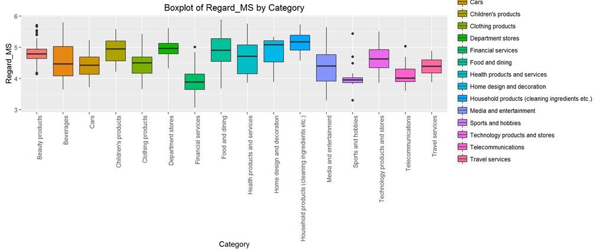

```r
tmp%>%select(Regard_MS,Category)%>%
ggplot(aes(Category,y=Regard_MS,fill=Category))+geom_boxplot()+
theme(axis.text.x = element_text(angle = 90, hjust = 1))+
ggtitle("Boxplot of Regard_MS by Category")
```